# Project: Investigate Movies Dataset

## >>>>>>>>>>>>>>>>>>>>>>>>>>>>>>>>>>>>>>>>>>>>>>>>>>>>>>>

## I can't see any relation between Drama and profit

## >>>>>>>>>>>>>>>>>>>>>>>>>>>>>>>>>>>>>>>>>>>>>>>>>>>>>>>

## make comparison between two datasets ( before and after 2000)

```python
data_before_2000 =data.query("year < 2000")
data_after_2000 = data.query("year >= 2000 ")
data_after_2000.year
```

```
0       2015
1       2015
2       2015
3       2015
4       2015
        ...
8883    2000
8884    2000
8885    2000
8886    2000
8887    2000
Name: year, Length: 7054, dtype: int64
```

```python
data_before_2000.describe()
```

|  | popularity | budget | revenue | runtime | vote_count | vote_average | year | profit |
| --- | --- | --- | --- | --- | --- | --- | --- | --- |
| count | 3677.000000 | 3.677000e+03 | 3.677000e+03 | 3677.000000 | 3677.000000 | 3677.000000 | 3677.000000 | 3.677000e+03 |
| mean | 0.557184 | 1.801327e+07 | 5.355826e+07 | 106.838999 | 143.429154 | 6.096002 | 1986.423987 | 2.276179e+07 |
| std | 0.676501 | 1.703577e+07 | 8.018691e+07 | 24.924427 | 402.672070 | 0.845961 | 10.419101 | 7.675608e+07 |
| min | 0.000188 | 1.000000e+00 | 2.000000e+00 | 3.000000 | 10.000000 | 1.500000 | 1960.000000 | -9.830110e+07 |
| 25% | 0.213085 | 1.480365e+07 | 2.800000e+07 | 93.000000 | 16.000000 | 5.600000 | 1980.000000 | 0.000000e+00 |
| 50% | 0.374104 | 1.480365e+07 | 4.031989e+07 | 103.000000 | 32.000000 | 6.100000 | 1989.000000 | 0.000000e+00 |
| 75% | 0.638429 | 1.480365e+07 | 4.031989e+07 | 116.000000 | 96.000000 | 6.700000 | 1995.000000 | 1.648873e+07 |
| max | 12.037933 | 2.000000e+08 | 1.845034e+09 | 566.000000 | 6351.000000 | 8.500000 | 1999.000000 | 1.645034e+09 |

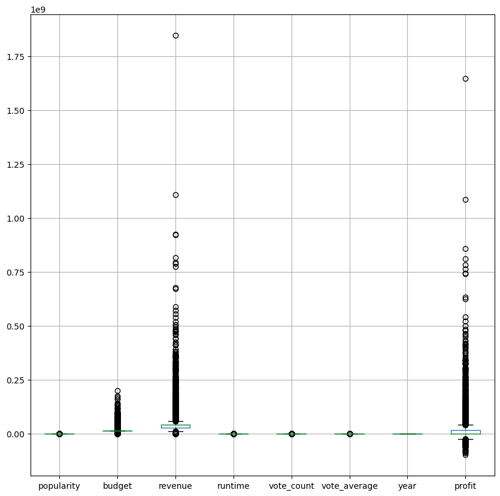

```python
data_before_2000.boxplot(figsize =(10,10));
```

```python
data_after_2000.describe()
```

|  | popularity | budget | revenue | runtime | vote_count | vote_average | year | profit |
| --- | --- | --- | --- | --- | --- | --- | --- | --- |
| count | 7054.000000 | 7.054000e+03 | 7.054000e+03 | 7054.000000 | 7054.000000 | 7054.000000 | 7054.000000 | 7.054000e+03 |
| mean | 0.702359 | 2.483667e+07 | 6.707435e+07 | 100.583782 | 259.629147 | 5.896272 | 2008.992912 | 2.695204e+07 |
| std | 1.135887 | 3.220990e+07 | 1.246708e+08 | 32.182734 | 648.500659 | 0.964334 | 4.347967 | 1.062174e+08 |
| min | 0.000620 | 1.000000e+00 | 2.000000e+00 | 3.000000 | 10.000000 | 1.500000 | 2000.000000 | -4.139124e+08 |
| 25% | 0.209598 | 1.480365e+07 | 4.031989e+07 | 90.000000 | 18.000000 | 5.300000 | 2006.000000 | 0.000000e+00 |
| 50% | 0.398340 | 1.480365e+07 | 4.031989e+07 | 97.000000 | 44.000000 | 5.900000 | 2010.000000 | 0.000000e+00 |
| 75% | 0.778152 | 1.921250e+07 | 4.031989e+07 | 109.000000 | 185.000000 | 6.600000 | 2013.000000 | 4.505597e+06 |
| max | 32.985763 | 4.250000e+08 | 2.781506e+09 | 900.000000 | 9767.000000 | 9.200000 | 2015.000000 | 2.544506e+09 |

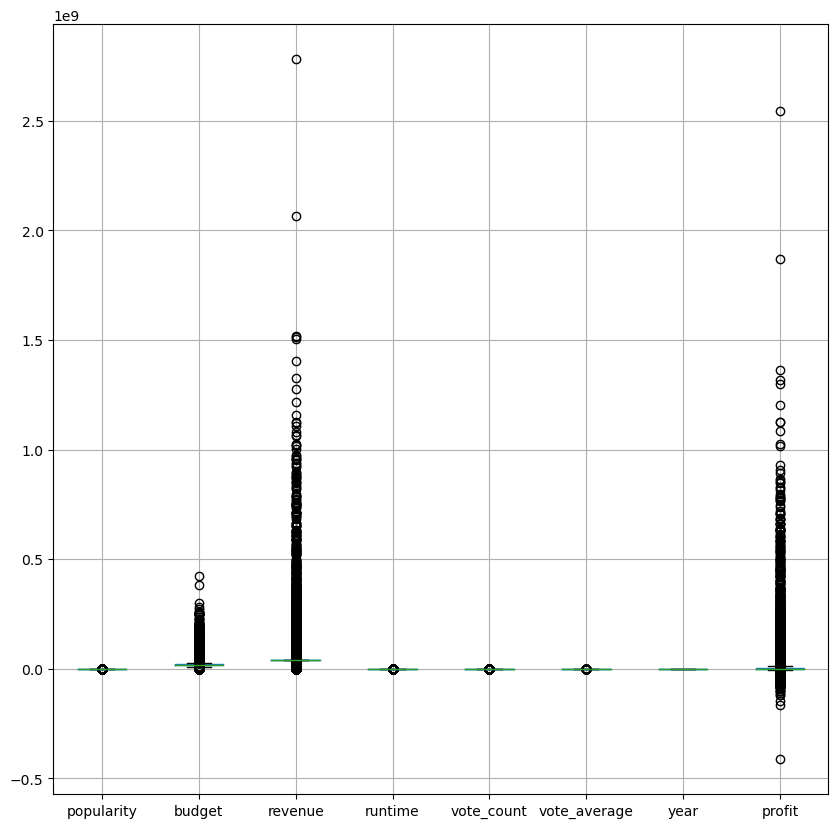

```python
data_after_2000.boxplot(figsize =(10,10));
```

## Acotors and movie category most involved and common

```python
Unique_cast_after_2000 =(convert_column(data_after_2000.cast))
Unique_cast_after_2000
```

```
{'Samuel L. Jackson': 49,
 'James Franco': 41,
 'Robert De Niro': 37,
 'Nicolas Cage': 36,
 'Colin Farrell': 34,
 'Bruce Willis': 34,
 'Morgan Freeman': 33,
 'Paul Giamatti': 33,
 'Julianne Moore': 32,
 'Jason Statham': 31,
 'Matt Damon': 31,
 'Liam Neeson': 31,
 'Woody Harrelson': 31,
 'Ewan McGregor': 31,
 'John Goodman': 31,
 'Guy Pearce': 31,
 'Owen Wilson': 31,
 'Susan Sarandon': 31,
 'John Cusack': 31,
 'Scarlett Johansson': 30,
 'Johnny Depp': 30,
 'Antonio Banderas': 30,
 'Ron Perlman': 30,
 'Rosario Dawson': 30,
 'Ray Liotta': 30,
 'Mark Wahlberg': 29,
 'Ryan Reynolds': 29,
 'Ben Kingsley': 29,
 'Steve Buscemi': 29,
 'Justin Long': 29,
 'Naomi Watts': 29,
 'Bill Nighy': 29,
 'Willem Dafoe': 29,
 'Cate Blanchett': 28,
 'Will Ferrell': 28,
 'Nicole Kidman': 28,
 'Danny Trejo': 28,
 'Catherine Keener': 28,
 'Mark Ruffalo': 27,
 'Paul Rudd': 27,
```

[output cut: 946 more lines]

```
 'William Mapother': 7,
 'Cobie Smulders': 7,
 'Matt Lanter': 7,
 'Justin Chatwin': 7,
 'Jason Alexander': 7,
 'Cameron Bright': 7,
 'Jonathan Pryce': 7,
 'Chris Noth': 7,
 'Regina Hall': 7,
 'William Sadler': 7,
 'Ray Romano': 7,
 'Denis Leary': 7,
 'Clea DuVall': 7,
 'Amber Tamblyn': 7,
 ...}
```

## >>>>>>>>>>>>>>>>>>>>>>>>>>>>>>>>>>>>>>>>>>>>>>>>>>>>>>>>>>>>>>>>>>>>>>>>

Samuel L. Jackson is the most Actor that involved in Movies after 2000

```python
Unique_cast_before_2000 =(convert_column(data_before_2000.cast))
Unique_cast_before_2000
```

```
{'Sean Connery': 38,
 'Clint Eastwood': 38,
 'Gene Hackman': 37,
 'Robert De Niro': 35,
 'Michael Caine': 30,
 'Harvey Keitel': 30,
 'Jack Nicholson': 30,
 ' Jr.': 28,
 'Bruce Willis': 28,
 'Robin Williams': 27,
 'Sylvester Stallone': 27,
 'Harrison Ford': 26,
 'Woody Allen': 26,
 'Dan Aykroyd': 26,
 'Nicolas Cage': 25,
 'Steve Martin': 25,
 'Arnold Schwarzenegger': 24,
 'Tom Hanks': 24,
 'John Travolta': 23,
 'Al Pacino': 23,
 'Donald Sutherland': 23,
 'Robert Duvall': 23,
 'Anthony Hopkins': 22,
 'Samuel L. Jackson': 22,
 'Mel Gibson': 22,
 'Christopher Lloyd': 22,
 'Michelle Pfeiffer': 22,
 'Christopher Lee': 22,
 'Peter Cushing': 21,
 'Christopher Walken': 21,
 'Danny DeVito': 21,
 'Jeff Bridges': 21,
 'Jean-Claude Van Damme': 21,
 'Eddie Murphy': 21,
 'Dennis Quaid': 21,
 'Whoopi Goldberg': 21,
 'Meryl Streep': 21,
 'Dustin Hoffman': 21,
 'Alec Baldwin': 21,
 'Charlie Sheen': 21,
```

[output cut: 946 more lines]

```
 'Peter Firth': 4,
 'Hart Bochner': 4,
 'Melissa Joan Hart': 4,
 'Jamie Foxx': 4,
 'TchÃ©ky Karyo': 4,
 'Tilda Swinton': 4,
 'Natasha Lyonne': 4,
 'Steven Weber': 4,
 'Dylan Baker': 4,
 'Colm Meaney': 4,
 'Tina Majorino': 4,
 'Patrick Bergin': 4,
 'Kieran Culkin': 4,
 'Loren Dean': 4,
 ...}
```

## >>>>>>>>>>>>>>>>>>>>>>>>>>>>>>>>>>>>>>>>>>>>>>>>>>>>>>>>>>>>

Sean Connery': 38, Clint Eastwood': 38, are the most Actors that involved in Movies before 2000

```python
Unique_Genre_before_2000 = convert_column(data_before_2000.genres)
```

```python
Unique_Genre_before_2000
```

```
{'Drama': 1688,
 'Comedy': 1397,
 'Thriller': 967,
 'Action': 925,
 'Romance': 634,
 'Adventure': 590,
 'Horror': 561,
 'Crime': 549,
 'Science Fiction': 494,
 'Family': 450,
 'Fantasy': 363,
 'Mystery': 308,
 'Music': 145,
 'Animation': 141,
 'History': 139,
 'War': 117,
 'Western': 110,
 'Foreign': 52,
 'Documentary': 48,
 'TV Movie': 38}
```

```python
Unique_Genre_after_2000 = convert_column(data_after_2000.genres)
```

```python
Unique_Genre_after_2000
```

```
{'Drama': 3058,
 'Comedy': 2378,
 'Thriller': 1935,
 'Action': 1451,
 'Horror': 1075,
 'Romance': 1074,
 'Adventure': 875,
 'Crime': 804,
 'Family': 764,
 'Science Fiction': 727,
 'Fantasy': 545,
 'Animation': 523,
 'Mystery': 500,
 'Documentary': 422,
 'Music': 254,
 'History': 191,
 'War': 151,
 'Foreign': 132,
 'TV Movie': 124,
 'Western': 54}
```

## >>>>>>>>>>>>>>>>>>>>>>>>>>>>>>>>>>>>>>>>>>>>>>>>>>>>>>>>>>>>

Drama is

the most Genre produced in MOvies Before and After 2000

## Percentage of Movies Numbers befor and after 2000

```python
int(data_after_2000.shape[0] )/int(data.shape[0]),int(data_before_2000.shape[0])/(int(data.shape[0]))
```

```
(0.6573478706551114, 0.34265212934488865)
```

## About 66% of Movies are preduced after 2000

#### >>>>>>>>>>>>>>>>>>>>>>>>>>>>>>>>>>>>>>>>>>>>>>>>>>>>>>>>>>>>>>>>>>>>>>>>>>>>>>>>>

Limitations:

> 1-The structures of Certain columns, like ‘cast’ and ‘genres’, contain multiple values separated by pipe (|) characters. make a limitation for more analytics like :

> > 1- what is the relation between profit and specific gener.

> > 2 - what is the relation between the cast and popularity of movies

> > 2- because of alot missing values in production_companies I droped the production_companies column . and this make a limitation for more analytics like

> > 1- what is the relation between the production_companies and popularity of movies.

> > 2- what is the relation between the production_companies and profit of movies.

Goal:

> we analyzed this amazing dataset and find intersting:What makes a profitable movie?

## Conclusions

from statistics:

3-There is a positive correlation between (budget , revenue , popularity) and profit

4 - September and October the most months which movies are produced by 23%.

5- 2014 ,2013 the most years which movies are produced .

6- The Story of Film: An Odyssey Movie in 2011 is the longest runtime movie by 900 min.

7- About 66% of Movies are preduced after 2000

8-Jurassic World Movie in 2015 is the most popular movie by 32.985763

9- Avatar Movie in 2009 is the Highest profit movie by 2544505847

10 - Woody Allen is the most director produced MOvies by 45 Movies 28%